### This document summarizes an attempt to build a simple machine learning algorithm, intended to predict from a sample data set how a barbell lift was performed.

## Preprocessing

### The data was first read in using the `read.csv()` function:

```r
training <- read.csv("pml-training.csv")
```

### The resulting data frame had 160 variables and 19,622 observations. The variables were rendered as one of three classes: numeric, integer, and factor. In addition, multiple columns had a number of entries where the contents were "" or NA. For consistency, all data columns were converted to numeric; at the same time, the first seven variables (index, user, timestamp, and window data) were discarded.

```r
## Create a vector with all of the columns' classes
columnClasses <- sapply(training,class)
## Convert all data columns to numeric
for(i in 8:159){
        if(columnClasses[i] != "numeric"){
            if(columnClasses[i] == "factor"){
                training[training[,i] == "",i] <- NA
                training[,i] <- as.numeric(as.character(training[,i]))
            }
            training[,i] <- as.numeric(training[,i])
        }
    }
## Remove the non-data columns
training <- training[,-c(1:7)]
```

### This, in turn, generated a number of columns with NAs. In fact, any columns with NAs consisted almost entirely of NA entries;

```r
NAcount <- sapply(training, function(x) sum(is.na(x)))
unique(NAcount)
```

```
##  [1]     0 19226 19248 19622 19225 19216 19294 19296 19227 19293 19221 19218
## [13] 19220 19217 19300 19301 19299
```

### The very small amount of data made any attempt to impute or otherwise fill in the data risky at best; as such, all columns with NA values were eliminated.

```r
training <- training[,ifelse(NAcount == 0, TRUE, FALSE)]
```

## Feature Selection

### In order to select the relevant features, the various variables were plotted graphically. To begin, the variables were plotted a few at a time using boxplots in R’s `featurePlot()` function, like so:

```r
featurePlot(x = training[,8:10], y = training$classe, plot = "box")
```

[output not shown]

### At this point, the plots were visually inspected. Any variable where the boxes for a single variable had some significant differences were then further inspected via a stacked histogram, such as this one for the accel_belt_z variable above:

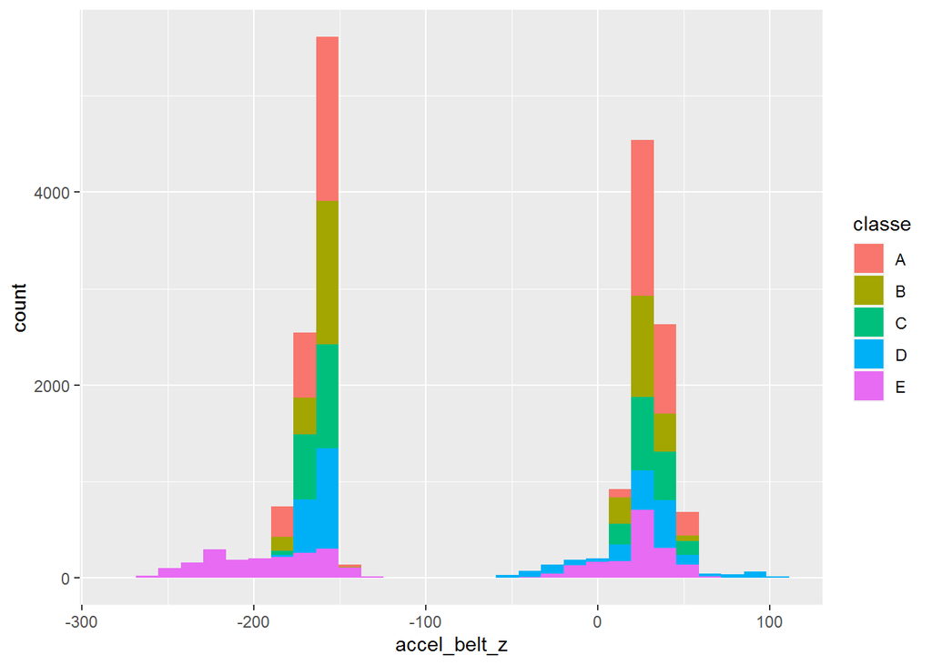

```r
ggplot(data = training, aes(x = accel_belt_z, fill = classe)) + geom_histogram()
```